# Pretest Analysis

Nicolas Restrepo

11/1/2019

## Preliminary Results

```r
# Packages

library(tidyverse)
library(knitr)
library(kableExtra)
theme_set(theme_light())
```

I am going to begin by loading in the data.

```r
# Load the data in

data <- read_csv("pretest.csv")

# Get rid of the first three rows which are uninformative

data <- data[-(1:3), ]
```

### Attention checks

First, it would be important to see who passed the attention checks.

```r
data <- data %>%
  mutate(passed_1 = ifelse(ach_1_1 == "extremely harmful", 1, 0),
         passed_2 = ifelse(ach_2_1 == "not at all immoral", 1, 0),
         passed_3 = ifelse(ach_3_1 == "moderately unexpected", 1, 0),
         passed_4 = ifelse(ach_4_1 == "not at all harmful", 1, 0),
         passed_5 = ifelse(ach_5_1 == "extremely immoral", 1, 0),
         passed_6 = ifelse(ach_6_1 == "extremely unexpected", 1, 0),
         sum_pass = passed_1 + passed_2 + passed_3 + passed_4 + passed_5 + passed_6)

# Now present the results in a table

table_passed <- data %>%
  select(PID, sum_pass) %>%
  group_by(sum_pass) %>%
  summarise( total = n())

kable(table_passed) %>%
  kable_styling(bootstrap_options = c("striped"), full_width = F, position = "center")
```

| sum_pass | total |
| --- | --- |
| 2 | 1 |
| 3 | 2 |
| 6 | 17 |

Overall we have three people who failed the attention checks. It seems that most people got them but, given that we only have 20 individuals, this is not an insubstantial number. Thus, this is worth bearing in mind. It might be useful to be more explicit about the attention checks in the instructions.

### Checking the Pre-Screening

For the purposes of this test, I told Prolific I only wanted liberal respondents. We can check whether the pre-screening did a good job.

```r
data_pol <- data %>%
  select(PID, ideology_1) %>%
  mutate(liberal = ifelse(ideology_1 == 1 | ideology_1 == 2 | ideology_1 == 3, 1, 0)) %>%
  group_by(liberal) %>%
  summarise(total = n())

kable(data_pol) %>%
  kable_styling(bootstrap_options = c("striped"), full_width = F, position = "center")
```

| liberal | total |
| --- | --- |
| 0 | 2 |
| 1 | 18 |

Surprisingly, we have two respondents who don’t identify as liberal. This can happen either because people have changed their minds since the time Prolific pre-screened them or because they are inconsistent with their answers. What we can do is confirm that the pre-screening is actually working by asking some of the demographic questions at the beginning. The question about ideology would be couched between other questions (such as race and gender) so that it is not too obvious. For the liberal sample, moderates and conservatives would become ineligible. We can add this skip logic to survey.

### Analyzing the Data

I am going to recode the data so we get numbers instead of strings:

```r
# Mutate all main questions

data_recoded <- data %>%
  mutate_at(vars(contains("_h_1")), funs(recode(.,
                                   "not at all harmful" = 1,
                                   "slightly harmful" = 2,
                                   "moderately harmful" = 3,
                                   "very harmful" = 4,
                                   "extremely harmful" = 5))) %>%
  mutate_at(vars(contains("_i_1")), funs(recode(.,
                                   "not at all immoral" = 1,
                                   "slightly immoral" = 2,
                                   "moderately immoral" = 3,
                                   "very immoral" = 4,
                                   "extremely immoral" = 5))) %>%
  mutate_at(vars(contains("_u_1")), funs(recode(.,
                                   "not at all unexpected" = 1,
                                   "slightly unexpected" = 2,
                                   "moderately unexpected" = 3,
                                   "very unexpected" = 4,
                                   "extremely unexpected" = 5)))
```

Now, I am going to focus solely on the responses to events:

```r
# Get of of the first set of uninformative columns

data_recoded <- data_recoded %>%
  select(-contains("ach")) %>%
  select(pkp_h_1:msas_u_1)

# Now let's create a more amenable dataset

d <- data_recoded %>%
  mutate(id = 1:n()) %>%
  select(id, everything())

# Rename all variables

d <- d %>%
  rename_all(
    funs(str_remove(., "_1"))
    ) %>%
  mutate_if(is.character, as.numeric)

# create a summary table for the values of each question

gd <- d %>%
  select(-id) %>%
  gather(key = "scenario",
         value = "score") %>%
  group_by(scenario) %>%
  summarise_all(funs(avg = mean(.), maximum = max(.), minimum = min(.), st_dv = sd(.))) %>%
  mutate(ci_lower = avg - 1.96*st_dv,
         ci_upper = avg + 1.96*st_dv)

gd <- gd %>%
  mutate(scenario = str_replace(scenario, "acr", "athlete_cheats_rival"),
         scenario = str_replace(scenario, "adr", "athlete_deceives_referee"),
         scenario = str_replace(scenario, "ayc", "athlete_yells_at_coach"),
         scenario = str_replace(scenario, "ccr", "coach_cheers_rival"),
         scenario = str_replace(scenario, "ddf", "daughter_disobeys_father"),
         scenario = str_replace(scenario, "ecc", "employee_conspires_with_comp."),
         scenario = str_replace(scenario, "elb", "employee_lies_to_boss"),
         scenario = str_replace(scenario, "git", "girl_interrupts_teacher"),
         scenario = str_replace(scenario, "idb", "intern_disobeys_boss"),
         scenario = str_replace(scenario, "jbd", "judge_befriends_defendant"),
         scenario = str_replace(scenario, "mbr", "man_betrays_relative"),
         scenario = str_replace(scenario, "mbw", "man_betrays_wife"),
         scenario = str_replace(scenario, "mmc", "man_marries_cousin"),
         scenario = str_replace(scenario, "mmls", "man_makes_love_sister"),
         scenario = str_replace(scenario, "mpsa", "married_has_sex_adulterer"),
         scenario = str_replace(scenario, "msas", "mother_sexually_arouses_son"),
         scenario = str_replace(scenario, "msn", "mayor_slanders_neighbor"),
         scenario = str_replace(scenario, "pch", "person_hurts_child"),
         scenario = str_replace(scenario, "php", "person_hires_prostitute"),
         scenario = str_replace(scenario, "pkp", "person_kills_person"),
         scenario = str_replace(scenario, "scc", "student_cheats_classmate"),
         scenario = str_replace(scenario, "sip", "student_insults_professor"),
         scenario = str_replace(scenario, "thls", "teacher_hits_lazy_student"),
         scenario = str_replace(scenario, "whh", "wife_hits_husband"),
         scenario = str_replace(scenario, "tmdp", "teenager_mocks_disabled"))
```

Now, we are in a position to start making some summary plots

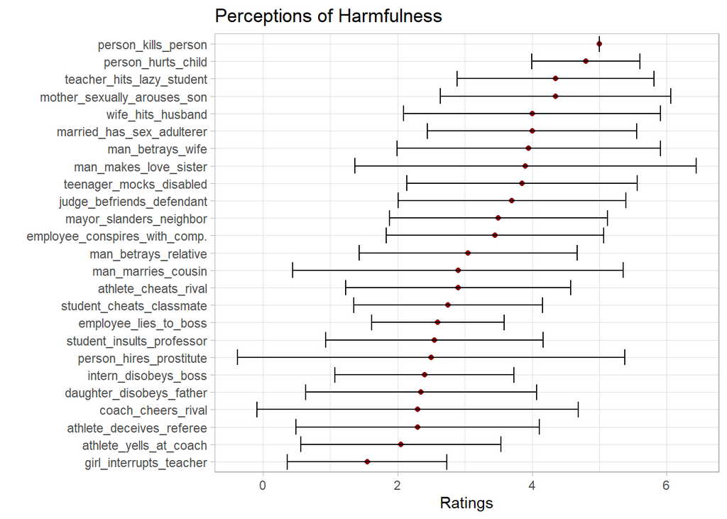

```r
# Keep only harm questions

gdh <- gd[str_which(gd$scenario, "_h$"),]

# Plot harm questions

gdh %>%
  mutate(scenario = str_remove(scenario, "_h$")) %>%
  ggplot(aes(x = reorder(scenario, avg), y = avg)) +
  geom_point(col = "darkred", fill = "darkred") +
  geom_errorbar(aes(ymin = ci_lower, ymax = ci_upper), pch = 0) +
  coord_flip() +
  labs(x = "",
       y = "Ratings",
       title = "Perceptions of Harmfulness")
```

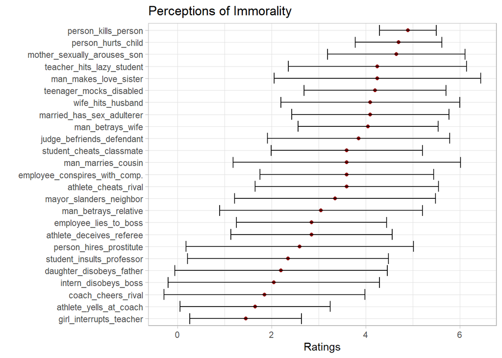

```r
# Now lets look at immorality

gdi <- gd[str_which(gd$scenario, "_i$"),]

# Plot immorality

gdi %>%
  mutate(scenario = str_remove(scenario, "_i$")) %>%
  ggplot(aes(x = reorder(scenario, avg), y = avg)) +
  geom_point(col = "darkred", fill = "darkred") +
  geom_errorbar(aes(ymin = ci_lower, ymax = ci_upper), pch = 0) +
  coord_flip() +
  labs(x = "",
       y = "Ratings",
       title = "Perceptions of Immorality")
```

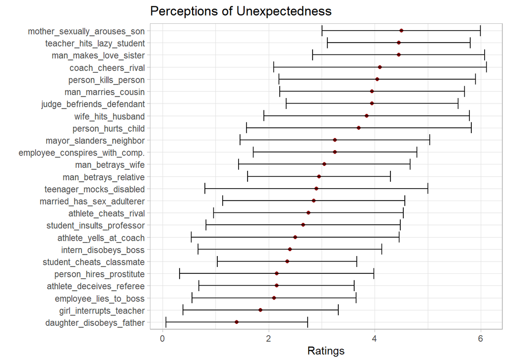

```r
# Lastly let's look at unexpectedness

gdu <- gd[str_which(gd$scenario, "_u$"),]

# Plot Unexpectedness

gdu %>%
  mutate(scenario = str_remove(scenario, "_u$")) %>%
  ggplot(aes(x = reorder(scenario, avg), y = avg)) +
  geom_point(col = "darkred", fill = "darkred") +
  geom_errorbar(aes(ymin = ci_lower, ymax = ci_upper), pch = 0) +
  coord_flip() +
  labs(x = "",
       y = "Ratings",
       title = "Perceptions of Unexpectedness")
```

The results look expected and encouraging. The events that involve the breaching of taboos are conistently rated as immoral and unexpected and yet there is great uncertainty around them. This reflects the idea that the wrongness of these events is not immediately obvious. It is also quite striking that everyone provided the same answer for the harmfulness of “person kills another person”. This indicates that the scenarios are indeed being interpreted as intended.